# Predicting Obesity Risk from Behavioral and Demographic Factors: A Comparative Analysis of Tree-Based Machine Learning Methods

GhafourianNasiri_Mohammad

2025-12-02

# Abstract

Obesity is a growing global health challenge, and this study aims to predict obesity levels based solely on lifestyle and eating habits. This study develops and compares four tree-based machine learning models to predict obesity classification from demographic and behavioral data. Models evaluated include single decision trees using deviance and Gini splitting criteria, bagging, and random forest. The dataset contains 531 observations with 15 predictor variables including age, height, water intake, eating frequency, physical activity, and family history. Random forest emerged as the best model with 31.8% total error and AUC of 0.75. Age and height are the strongest predictors of obesity, followed by behavioral factors like water intake and eating frequency. Ensemble methods significantly outperform single trees, with random forest achieving 31.8% error compared to 33.6% for single decision trees. The main challenge is classifying overweight cases due to class imbalance and overlap with other obesity categories. Results show that demographic and lifestyle factors can predict obesity reasonably well, but prediction accuracy varies across obesity classes.

# Introduction

## Background and Motivation

Obesity is a major public health challenge. The World Health Organization (WHO) reports that global obesity prevalence has nearly tripled since 1975. Current data indicates that over one billion people live with obesity, including approximately 890 million adults and 160 million children and adolescents. Incidence rates are rising in low- and middle-income countries, where healthcare systems often face a dual burden of malnutrition and metabolic disease. This condition drives non-communicable diseases, including type 2 diabetes, cardiovascular disease, and cancer, through mechanisms such as systemic inflammation and insulin resistance. The economic impact of obesity is substantial. The World Obesity Federation projects that the global cost of overweight and obesity will reach $4.32 trillion annually by 2035, equivalent to nearly 3% of global GDP. Indirect costs, stemming from lost workforce productivity, absenteeism, and premature mortality, often exceed direct medical expenditures. Consequently, the failure to address obesity affects national economies alongside healthcare systems. Addressing this challenge requires moving from reactive management to early identification. Current screening relies on Body Mass Index (BMI), a lagging indicator that may not capture body composition nuances or identify risk before weight gain occurs. Predictive tools that identify at-risk individuals based on modifiable behaviors, such as diet and physical activity, are necessary. This study addresses this gap by developing and benchmarking machine learning classification models to predict obesity status using demographic and lifestyle characteristics.

## Dataset Description

### Data Source

The dataset originates from the study by Palechor and de la Hoz Manotas (2019), titled *“Dataset for estimation of obesity levels based on eating habits and physical condition in individuals from Colombia, Peru and Mexico.”* Data was collected via an online questionnaire administered to individuals aged 14-61 years residing in Colombia, Peru, and Mexico. The original dataset contains 2,111 observations. However, approximately 75% of these observations were synthetically generated using SMOTE (Synthetic Minority Over-sampling Technique) to balance the obesity classes. This synthetic augmentation is a critical consideration addressed in our data preparation.

### Variable Descriptions

The following table describes all variables in the dataset:

| Variable | Type | Description | Levels/Units |
| --- | --- | --- | --- |
| **Demographic Variables** |  |  |  |
| Gender | Categorical | Biological sex | Female, Male |
| Age | Numeric | Age in years | 14-61 years |
| Height | Numeric | Height | Meters |
| Weight | Numeric | Weight | Kilograms |
| **Eating Habits** |  |  |  |
| FAVC | Binary | Frequent consumption of high-calorie food | No, Yes |
| FCVC | Ordinal | Frequency of vegetable consumption | 1=Never, 2=Sometimes, 3=Always |
| NCP | Ordinal | Number of main meals per day | 1, 2, 3, 4+ |
| CAEC | Categorical | Consumption of food between meals | No, Sometimes, Frequently, Always |
| CH2O | Ordinal | Daily water consumption | 1=Low, 2=Medium, 3=High |
| CALC | Categorical | Alcohol consumption frequency | No, Sometimes, Frequently, Always |
| **Lifestyle Variables** |  |  |  |
| SMOKE | Binary | Smoking status | No, Yes |
| SCC | Binary | Calorie consumption monitoring | No, Yes |
| FAF | Ordinal | Physical activity frequency | 0=None, 1=1-2 days, 2=2-4 days, 3=4+ days |
| TUE | Ordinal | Time using technology devices | 0=0-3h, 1=3-5h, 2=5h+ |
| MTRANS | Categorical | Transportation used | Automobile, Bike, Motorbike, Public Transport, Walking |
| family_history_with_overweight | Binary | Family history of overweight | No, Yes |
| **Target Variable** |  |  |  |
| NObeyesdad | Categorical | Obesity level classification | 7 levels (Insufficient Weight to Obesity Type III) |

## Research Questions

This analysis addresses the following research question:

What demographic and behavioral factors best predict obesity risk, and which machine learning method provides the most accurate classification?

# Data Preparation

```r
library(tree)
library(randomForest)
library(pROC)
library(ggplot2)
library(knitr)
library(kableExtra)
set.seed(123)
```

## Real vs. Synthetic Data Separation

### Rationale

The original dataset contains both real survey responses and synthetically generated observations (via SMOTE). Using synthetic data may introduce artifacts that do not reflect human behavior patterns. To ensure our findings are valid and generalizable, we identify and filter out synthetic observations.

**Identification Method:** Real survey responses have integer values for variables FCVC, NCP, CH2O, FAF, and TUE, while SMOTE-generated records contain decimal values due to the interpolation process.

```r
obesity <- read.csv("ObesityDataSet_raw_and_data_sinthetic.csv")
is_decimal <- function(x) { return((x %% 1) != 0)}
obesity$data_type <- "Real"
synthetic_indices <- which( is_decimal(obesity$FCVC) |is_decimal(obesity$NCP) | is_decimal(obesity$CH2O) | is_decimal(obesity$FAF) | is_decimal(obesity$TUE))
obesity$data_type[synthetic_indices] <- "Synthetic"
table(obesity$data_type)
```

```
##
##      Real Synthetic
##       531      1580
```

```r
prop.table(table(obesity$data_type)) * 100
```

```
##
##      Real Synthetic
##  25.15396  74.84604
```

```r
obesity_real <- obesity[obesity$data_type == "Real", ]
```

### Interpretation

We proceed with only the 531 real observations to ensure validity of findings.

## Variable Transformations

### Factor Conversions

All categorical variables must be properly converted to R factors for modeling. This ensures correct treatment in tree-based methods.

```r
# Convert binary variables: FAVC, SMOKE, SCC, family_history, Gender
obesity_real$FAVC  <- factor(obesity_real$FAVC,  levels = c("no", "yes"))
obesity_real$SMOKE <- factor(obesity_real$SMOKE, levels = c("no", "yes"))
obesity_real$SCC   <- factor(obesity_real$SCC,   levels = c("no", "yes"))
obesity_real$family_history_with_overweight <- factor(obesity_real$family_history_with_overweight,levels = c("no", "yes"))
obesity_real$Gender <- factor(obesity_real$Gender, levels = c("Female", "Male"))
# Convert ordinal variables: FCVC, CH2O, FAF, TUE
obesity_real$FCVC <- factor(obesity_real$FCVC, levels = c(1, 2, 3), ordered = TRUE)
obesity_real$CH2O <- factor(obesity_real$CH2O, levels = c(1, 2, 3), ordered = TRUE)
obesity_real$FAF <- factor(obesity_real$FAF, levels = c(0, 1, 2, 3), ordered = TRUE)
obesity$NCP  <- factor(obesity$NCP,  levels = c(1, 2, 3, 4))
obesity_real$TUE <- factor(obesity_real$TUE, levels = c(0, 1, 2), ordered = TRUE)
# Convert nominal variables: CAEC, MTRANS, NObeyesdad
obesity_real$CAEC <- factor(obesity_real$CAEC, levels = c("no", "Sometimes", "Frequently", "Always"))
obesity$CALC <- factor(obesity$CALC,levels = c("no", "Sometimes", "Frequently", "Always"))
obesity$MTRANS <- factor(obesity$MTRANS, levels = c("Automobile", "Bike", "Motorbike", "Public_Transportation", "Walking"))
obesity$NObeyesdad <- factor(obesity$NObeyesdad,levels=c("Insufficient_Weight","Normal_Weight","Overweight_Level_I","Overweight_Level_II","Obesity_Type_I","Obesity_Type_II","Obesity_Type_III"))
str(obesity_real)
```

```
## 'data.frame':    531 obs. of  18 variables:
##  $ Gender                        : Factor w/ 2 levels "Female","Male": 1 1 2 2 2 2 1 2 2 2 ...
##  $ Age                           : num  21 21 23 27 22 29 23 22 24 22 ...
##  $ Height                        : num  1.62 1.52 1.8 1.8 1.78 1.62 1.5 1.64 1.78 1.72 ...
##  $ Weight                        : num  64 56 77 87 89.8 53 55 53 64 68 ...
##  $ family_history_with_overweight: Factor w/ 2 levels "no","yes": 2 2 2 1 1 1 2 1 2 2 ...
##  $ FAVC                          : Factor w/ 2 levels "no","yes": 1 1 1 1 1 2 2 1 2 2 ...
##  $ FCVC                          : Ord.factor w/ 3 levels "1"<"2"<"3": 2 3 2 3 2 2 3 2 3 2 ...
##  $ NCP                           : num  3 3 3 3 1 3 3 3 3 3 ...
##  $ CAEC                          : Factor w/ 4 levels "no","Sometimes",..: 2 2 2 2 2 2 2 2 2 2 ...
##  $ SMOKE                         : Factor w/ 2 levels "no","yes": 1 2 1 1 1 1 1 1 1 1 ...
##  $ CH2O                          : Ord.factor w/ 3 levels "1"<"2"<"3": 2 3 2 2 2 2 2 2 2 2 ...
##  $ SCC                           : Factor w/ 2 levels "no","yes": 1 2 1 1 1 1 1 1 1 1 ...
##  $ FAF                           : Ord.factor w/ 4 levels "0"<"1"<"2"<"3": 1 4 3 3 1 1 2 4 2 2 ...
##  $ TUE                           : Ord.factor w/ 3 levels "0"<"1"<"2": 2 1 2 1 1 1 1 1 2 2 ...
##  $ CALC                          : chr  "no" "Sometimes" "Frequently" "Frequently" ...
##  $ MTRANS                        : chr  "Public_Transportation" "Public_Transportation" "Public_Transportation" "Walking" ...
##  $ NObeyesdad                    : chr  "Normal_Weight" "Normal_Weight" "Normal_Weight" "Overweight_Level_I" ...
##  $ data_type                     : chr  "Real" "Real" "Real" "Real" ...
```

### Merging Rare Factor Levels

Several categorical variables contain levels with very few observations, which can cause modeling issues. We merge these into meaningful grouped categories.

#### Transportation Mode (MTRANS)

```r
cat("Original MTRANS Counts:\n")
```

```
## Original MTRANS Counts:
```

```r
print(table(obesity_real$MTRANS))
```

```
##
##            Automobile                  Bike             Motorbike
##                   107                     7                    11
## Public_Transportation               Walking
##                   351                    55
```

```r
obesity_real$MTRANS_3 <- as.character(obesity_real$MTRANS)
obesity_real$MTRANS_3[obesity_real$MTRANS %in% c("Bike", "Walking")] <- "Active"
obesity_real$MTRANS_3[obesity_real$MTRANS %in% c("Automobile", "Motorbike")] <- "Private_Motor"
obesity_real$MTRANS_3[obesity_real$MTRANS == "Public_Transportation"] <- "Public_Transport"
obesity_real$MTRANS_3 <- factor(obesity_real$MTRANS_3, levels = c("Active", "Private_Motor", "Public_Transport"))
cat("\nMerged MTRANS_3 Counts:\n")
```

```
##
## Merged MTRANS_3 Counts:
```

```r
print(table(obesity_real$MTRANS_3))
```

```
##
##           Active    Private_Motor Public_Transport
##               62              118              351
```

**Rationale:** The categories “Bike” and “Motorbike” had extremely low frequencies, leading to sparsity. To address this, we grouped categories based on physical exertion: “Active” (Walking and Bike) and “Private Motor” (Automobile and Motorbike).

#### Number of Meals (NCP)

```r
cat("Original NCP Counts:\n")
```

```
## Original NCP Counts:
```

```r
print(table(obesity_real$NCP))
```

```
##
##   1   3   4
## 124 359  48
```

```r
obesity_real$NCP_3 <- NA_character_
ncp_numeric <- as.numeric(as.character(obesity_real$NCP)) # Ensure we treat it as number for logic
obesity_real$NCP_3[ncp_numeric <= 2] <- "Low_1-2"
obesity_real$NCP_3[ncp_numeric == 3] <- "Normal_3"
obesity_real$NCP_3[ncp_numeric >= 4] <- "High_4+"
obesity_real$NCP_3 <- factor(obesity_real$NCP_3, levels = c("Low_1-2", "Normal_3", "High_4+"))
cat("\nMerged NCP_3 Counts:\n")
```

```
##
## Merged NCP_3 Counts:
```

```r
print(table(obesity_real$NCP_3))
```

```
##
##  Low_1-2 Normal_3  High_4+
##      124      359       48
```

**Rationale:** Most people consume 3 meals a day (Normal). Those eating 1 or 2 meals likely have caloric deficits or skipping habits, while 4+ suggests frequent eating.

#### Alcohol Consumption (CALC)

```r
print(table(obesity_real$CALC))
```

```
##
##     Always Frequently         no  Sometimes
##          1         45        191        294
```

```r
obesity_real$CALC_3 <- as.character(obesity_real$CALC)
obesity_real$CALC_3[obesity_real$CALC == "no"] <- "No"
obesity_real$CALC_3[obesity_real$CALC == "Sometimes"] <- "Sometimes"
obesity_real$CALC_3[obesity_real$CALC %in% c("Frequently", "Always")] <- "Frequent"
obesity_real$CALC_3 <- factor(obesity_real$CALC_3, levels = c("No", "Sometimes", "Frequent"))
print(table(obesity_real$CALC_3))
```

```
##
##        No Sometimes  Frequent
##       191       294        46
```

**Rationale:** The “Always” category contained negligible observations in the real dataset. We merged “Always” with “Frequently” into a single “Frequent” category.

### Binning Continuous Variables

Continuous variables (Age, Height) are binned into quantile-based categories to avoid assumptions of linear relationships.

```r
make_quantile_bins <- function(x, n_bins = 5, labels = NULL) {
  probs <- seq(0, 1, length.out = n_bins + 1)
  qs <- unique(quantile(x, probs = probs, na.rm = TRUE))
  # Create bins
  cut(x, breaks = qs, include.lowest = TRUE, labels = labels[1:(length(qs)-1)])}
obesity_real$Age_bin5 <- make_quantile_bins( obesity_real$Age,n_bins = 5, labels = c("Very_Young", "Young", "Adult", "Mature", "Older"))
obesity_real$Height_bin5 <- make_quantile_bins( obesity_real$Height, n_bins = 5,labels = c("Very_Short", "Short", "Medium", "Tall", "Very_Tall"))
print(table(obesity_real$Age_bin5))
```

```
##
## Very_Young      Young      Adult     Mature      Older
##        110        176         37        113         95
```

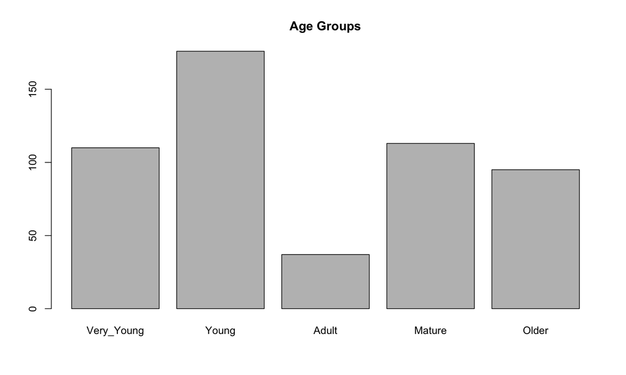

```r
barplot(table(obesity_real$Age_bin5), main="Age Groups", col="gray")
```

```r
print(table(obesity_real$Height_bin5))
```

```
##
## Very_Short      Short     Medium       Tall  Very_Tall
##        125        105         96         99        106
```

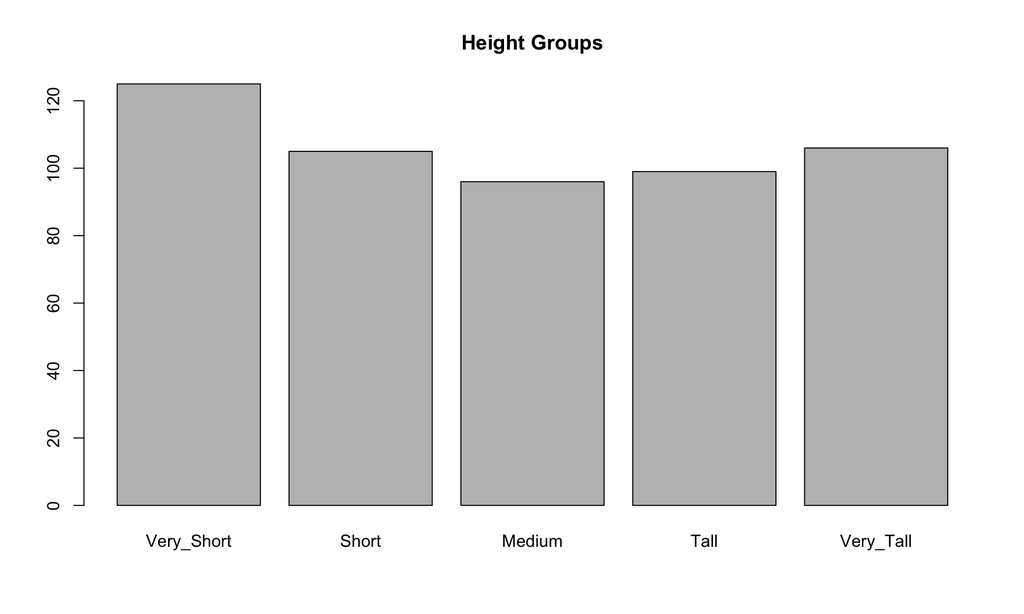

```r
barplot(table(obesity_real$Height_bin5), main="Height Groups", col="gray")
```

**Note on Weight:** Weight is intentionally **excluded** from the predictor set because obesity classification is derived from BMI (which uses weight). Including weight create circular logic and inflate model performance.

### Target Variable Creation

The original 7-class target variable is grouped into 3 classes to improve model stability given our reduced sample size.

```r
obesity_real$Obesity_3 <- NA_character_
obesity_real$Obesity_3[obesity_real$NObeyesdad %in% c("Insufficient_Weight", "Normal_Weight")] <- "Normal_or_Under"
obesity_real$Obesity_3[obesity_real$NObeyesdad %in% c("Overweight_Level_I", "Overweight_Level_II")] <- "Overweight"
obesity_real$Obesity_3[obesity_real$NObeyesdad %in% c("Obesity_Type_I", "Obesity_Type_II", "Obesity_Type_III")] <- "Obese"
obesity_real$Obesity_3 <- factor(obesity_real$Obesity_3, levels = c("Normal_or_Under", "Overweight", "Obese"))
cat("--- Target Variable Distribution (3 Classes) ---\n")
```

```
## --- Target Variable Distribution (3 Classes) ---
```

```r
print(table(obesity_real$Obesity_3))
```

```
##
## Normal_or_Under      Overweight           Obese
##             327             132              72
```

```r
print(prop.table(table(obesity_real$Obesity_3)) * 100) # Show percentages
```

```
##
## Normal_or_Under      Overweight           Obese
##        61.58192        24.85876        13.55932
```

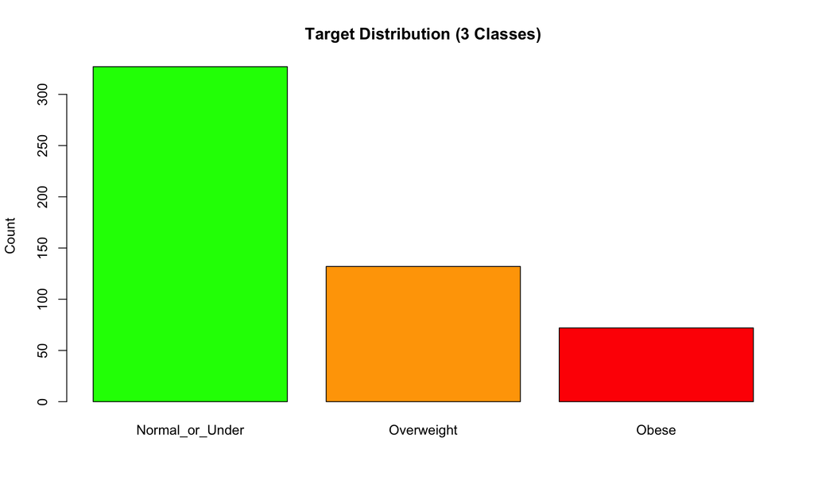

```r
barplot(table(obesity_real$Obesity_3),
        main = "Target Distribution (3 Classes)",
        col = c("green", "orange", "red"),
        ylab = "Count")
```

**Rationale:** With only 531 real observations, the 7-class problem would have insufficient samples per class for reliable modeling. The 3-class grouping ensure adequate class sizes.

## Train/Test Split

```r
set.seed(123)
n <- nrow(obesity_real)
train_size <- floor(0.8 * n)
train_index <- sample(1:n, size = train_size, replace = FALSE)
ob_train <- obesity_real[train_index, ]
ob_test  <- obesity_real[-train_index, ]
```

### Class Distribution Verification

| Class | Training Set (n=424) | Test Set (n=107) |
| --- | --- | --- |
| Normal_or_Under | 62% | 59.8% |
| Overweight | 25% | 24.3% |
| Obese | 13% | 15.9% |

The similar class distributions confirm that our random split produced representative training and test sets.

## Final Predictor Set

Based on the transformations above, our final predictor set consists of 15 variables:

```r
allowed_predictors <- c("Gender","Age_bin5","Height_bin5","family_history_with_overweight","FAVC",
  "FCVC","CAEC","SMOKE","CH2O","SCC","FAF","TUE","NCP_3","CALC_3","MTRANS_3")
```

**Excluded variables:**

- **Weight:** Circular relationship with target (BMI uses weight)
- **Height (raw):** Replaced with Height_bin5
- **Age (raw):** Replaced with Age_bin5
- **Original MTRANS, NCP, CALC:** Replaced with merged versions

# Exploratory Data Analysis

## Target Variable Distribution

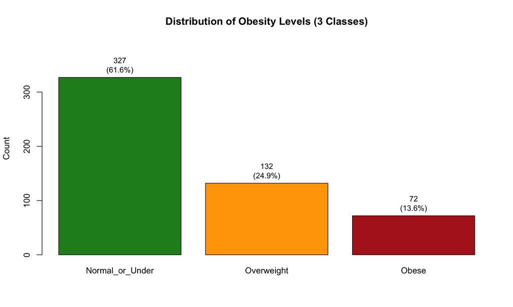

```r
target_counts <- table(obesity_real$Obesity_3)
target_pct <- round(prop.table(target_counts) * 100, 1)
bp <- barplot(target_counts, main = "Distribution of Obesity Levels (3 Classes)", col = c("forestgreen", "orange", "firebrick"), ylim = c(0, max(target_counts) * 1.2),ylab = "Count")
text(x = bp, y = target_counts, labels = paste0(target_counts, "\n(", target_pct, "%)"), pos = 3, cex = 0.9)
```

### Interpretation

The distribution of the target variable is clearly imbalanced. This class imbalance implies that Models may naturally favor the majority class. methods robust to uneven class sizes such as Random Forest may work better when predicting obesity levels.

## Predictor Distributions

### Demographic Variables

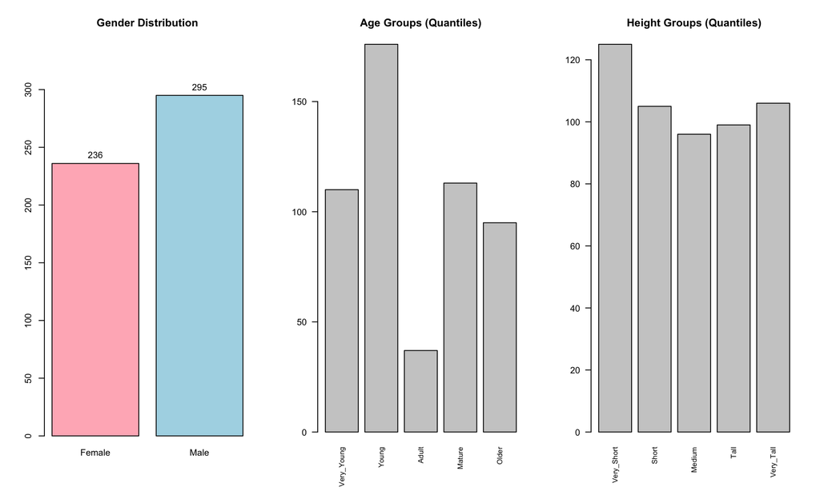

```r
par(mfrow = c(1, 3))
gender_counts <- table(obesity_real$Gender)
bp_g <- barplot(gender_counts, main = "Gender Distribution", col = c("lightpink", "lightblue"),ylim = c(0, max(gender_counts) * 1.15))
text(bp_g, gender_counts, labels = gender_counts, pos = 3)
age_counts <- table(obesity_real$Age_bin5)
bp_a <- barplot(age_counts, main = "Age Groups (Quantiles)", col = "gray80",las = 2,cex.names = 0.8)
height_counts <- table(obesity_real$Height_bin5)
bp_h <- barplot(height_counts, main = "Height Groups (Quantiles)", col = "gray80",las = 2,cex.names = 0.8)
```

```r
par(mfrow = c(1, 1))
```

**Key observations:**

- There is no severe gender imbalance that would bias the model toward one group. Height and Age is unlikely to introduce bias. It may play a role indirectly, as height interacts with BMI-related physiology.

### Eating Habit Variables

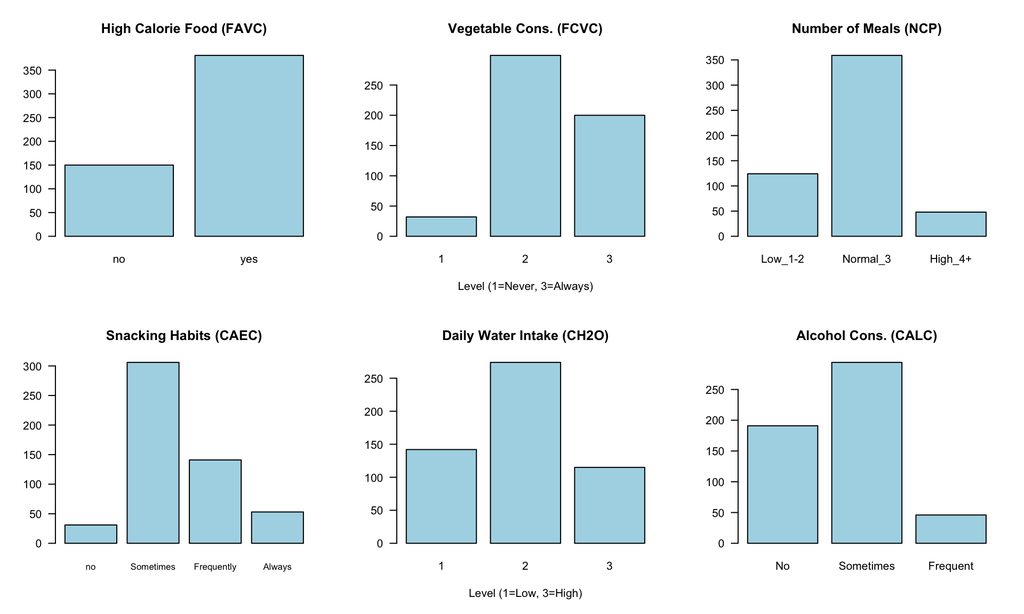

```r
par(mfrow = c(2, 3))
barplot(table(obesity_real$FAVC),main = "High Calorie Food (FAVC)", col = "lightblue", las = 1)
barplot(table(obesity_real$FCVC), main = "Vegetable Cons. (FCVC)", xlab = "Level (1=Never, 3=Always)",col = "lightblue", las = 1)
barplot(table(obesity_real$NCP_3),main = "Number of Meals (NCP)",col = "lightblue", las = 1)
barplot(table(obesity_real$CAEC), main = "Snacking Habits (CAEC)",col = "lightblue", las = 1, cex.names = 0.8)
barplot(table(obesity_real$CH2O), main = "Daily Water Intake (CH2O)",xlab = "Level (1=Low, 3=High)",col = "lightblue", las = 1)
barplot(table(obesity_real$CALC_3), main = "Alcohol Cons. (CALC)", col = "lightblue", las = 1)
```

```r
par(mfrow = c(1, 1))
```

### Lifestyle Variables

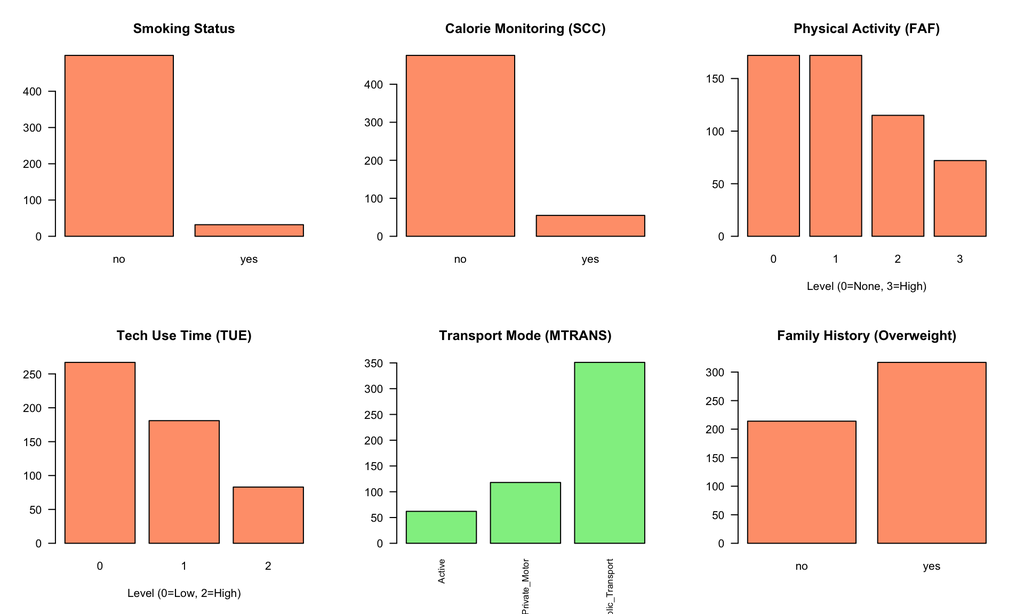

```r
par(mfrow = c(2, 3))

barplot(table(obesity_real$SMOKE),main = "Smoking Status", col = "lightsalmon", las = 1)
barplot(table(obesity_real$SCC),main = "Calorie Monitoring (SCC)", col = "lightsalmon", las = 1)
barplot(table(obesity_real$FAF),main = "Physical Activity (FAF)", xlab = "Level (0=None, 3=High)",col = "lightsalmon", las = 1)
barplot(table(obesity_real$TUE), main = "Tech Use Time (TUE)", xlab = "Level (0=Low, 2=High)",col = "lightsalmon", las = 1)
barplot(table(obesity_real$MTRANS_3), main = "Transport Mode (MTRANS)", col = "lightgreen", las = 2, cex.names = 0.8)
barplot(table(obesity_real$family_history_with_overweight), main = "Family History (Overweight)", col = "lightsalmon", las = 1)
```

```r
par(mfrow = c(1, 1))
```

## Relationships with Target

### Key Predictor-Target Associations

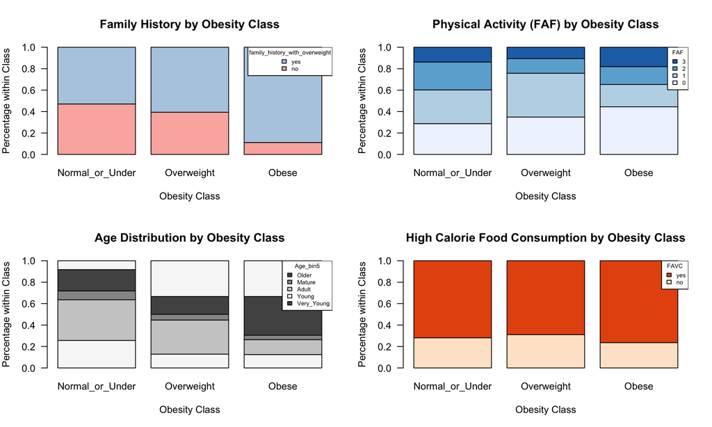

```r
plot_bivariate_base <- function(data, x_var, fill_var, title, col_palette = NULL) {tab <- table(data[[x_var]], data[[fill_var]])
prop_tab <- prop.table(tab, margin = 1)
  if (is.null(col_palette)) {col_palette <- rainbow(ncol(prop_tab))}
  barplot(t(prop_tab), beside = FALSE,col = col_palette,main = title,xlab = "Obesity Class", ylab = "Percentage within Class",ylim = c(0, 1),las = 1)
  legend("topright", legend = rev(colnames(prop_tab)),  fill = rev(col_palette),title = fill_var,cex = 0.6,bty = "o",bg = "white")   }
par(mfrow = c(2, 2), mar = c(5, 4, 4, 2))
col_pastel1 <- c("#FBB4AE", "#B3CDE3")
plot_bivariate_base(obesity_real, "Obesity_3", "family_history_with_overweight", "Family History by Obesity Class", col_pastel1)
col_blues <- c("#EFF3FF", "#BDD7E7", "#6BAED6", "#2171B5")
plot_bivariate_base(obesity_real, "Obesity_3", "FAF", "Physical Activity (FAF) by Obesity Class", col_blues)
col_greys <- c("#F7F7F7", "#CCCCCC", "#969696", "#525252")
plot_bivariate_base(obesity_real, "Obesity_3", "Age_bin5", "Age Distribution by Obesity Class", col_greys)
col_oranges <- c("#FEE6CE", "#E6550D")
plot_bivariate_base(obesity_real, "Obesity_3", "FAVC", "High Calorie Food Consumption by Obesity Class", col_oranges)
```

```r
par(mfrow = c(1, 1))
```

# Methodology

## Decision Trees

Decision trees partition the predictor space into regions through recursive binary splitting. At each node, the algorithm selects the variable and split point that best separates the classes according to an impurity measure.

**Splitting Criteria:**

- **Deviance (Entropy):** Measures information gain; prefers splits that create purer nodes
- **Gini Index:** Measures class probability dispersion; commonly used in CART

**Cross-Validation for Tree Size:** Large trees tend to overfit the training data. We use K-fold cross-validation to identify the optimal tree size that minimizes prediction error on held-out data.

**Pruning:** After determining the optimal size via cross-validation, we prune the tree by removing splits that do not improve cross-validated performance. This produces a simpler, more generalizable model.

**R Implementation:** We use the `tree` package with `cv.tree()` for cross-validation and `prune.misclass()` for pruning based on misclassification rate.

## Bagging (Bootstrap Aggregating)

Bagging reduces variance by training multiple trees on bootstrap samples of the training data and averaging their predictions.

**Key characteristics:**

- Each tree is trained on a bootstrap sample (sampling with replacement)
- At each split, **all p predictors** are considered (mtry = p)
- Final prediction is by majority vote across all trees
- Out-of-bag (OOB) observations provide built-in validation

**R Implementation:** We use `randomForest()` with `mtry = p` (number of predictors = 15) and `ntree = 500`.

## Random Forest

Random Forest extends bagging by introducing additional randomness: at each split, only a random subset of predictors is considered.

**Key characteristics:**

- Same bootstrap sampling as bagging
- At each split, only **√p predictors** are randomly selected (mtry ≈ 4 for our 15 predictors)
- This decorrelates the trees, further reducing variance
- Variable importance measures indicate predictor contributions

**R Implementation:** We use `randomForest()` with default mtry (√p for classification) and `ntree = 500`.

# Results

## Decision Tree Results

### Model 1: Deviance-Based Tree

```r
train_data <- ob_train[, c("Obesity_3", allowed_predictors)]
test_data  <- ob_test[, c("Obesity_3", allowed_predictors)]
tree_deviance <- tree(Obesity_3 ~ ., data = train_data, split = "deviance")
summary(tree_deviance)
```

```
##
## Classification tree:
## tree(formula = Obesity_3 ~ ., data = train_data, split = "deviance")
## Variables actually used in tree construction:
##  [1] "Age_bin5"                       "CAEC"
##  [3] "Height_bin5"                    "FAVC"
##  [5] "CH2O"                           "CALC_3"
##  [7] "family_history_with_overweight" "TUE"
##  [9] "NCP_3"                          "FAF"
## Number of terminal nodes:  18
## Residual mean deviance:  1.319 = 535.5 / 406
## Misclassification error rate: 0.2642 = 112 / 424
```

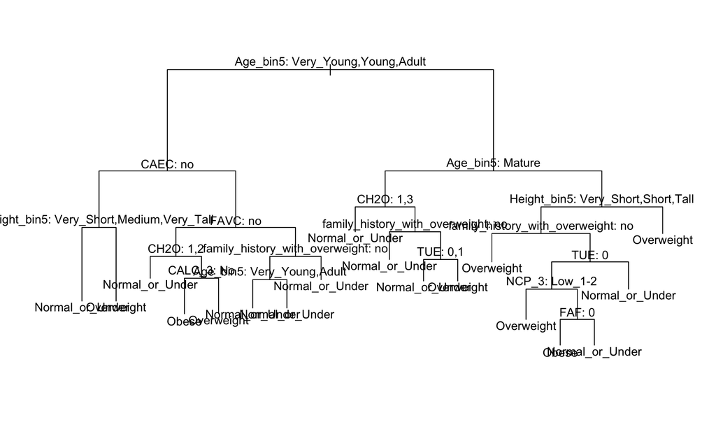

```r
plot(tree_deviance); text(tree_deviance, pretty=0)
```

Our Deviance tree model predicts obesity classification using 18 different groups based on 10 variables. The model correctly classifies about 73.6% of cases, which means it makes mistakes about 26.4% of the time. Age is the first split, and then the model uses eating frequency, height, and water consumption to make further decisions. The error rate shows that obesity is hard to predict with just these features because different obesity groups have similar characteristics.

#### Cross-Validation for Optimal Size

```r
set.seed(2024)
cv_deviance <- cv.tree(tree_deviance, FUN = prune.misclass)
print(cv_deviance)
```

```
## $size
## [1] 18 16 10  6  5  1
##
## $dev
## [1] 158 157 151 154 156 162
##
## $k
## [1] -Inf 0.00 1.00 3.50 4.00 6.25
##
## $method
## [1] "misclass"
##
## attr(,"class")
## [1] "prune"         "tree.sequence"
```

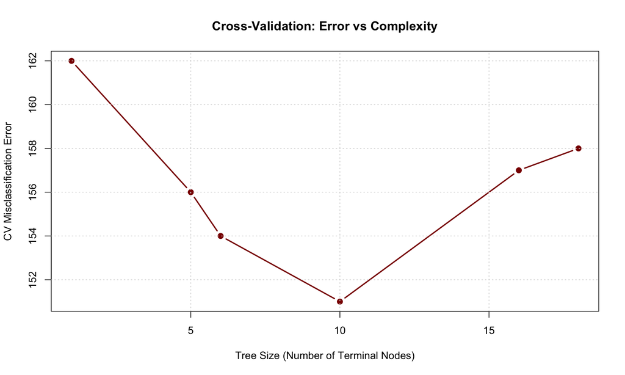

```r
plot(cv_deviance$size, cv_deviance$dev, type = "b", pch = 19, col = "darkred", lwd = 2,xlab = "Tree Size (Number of Terminal Nodes)", ylab = "CV Misclassification Error",main = "Cross-Validation: Error vs Complexity")
grid()
```

```r
best_size_dev <- cv_deviance$size[which.min(cv_deviance$dev)]
cat("\nOptimal Tree Size (Nodes):", best_size_dev, "\n")
```

```
##
## Optimal Tree Size (Nodes): 10
```

Cross-validation was used to find the best tree size that balances accuracy and simplicity. The results show that a tree with 10 nodes has the lowest cross-validation error of 151 misclassifications. This is better than the original tree with 18 nodes, which had 158 errors. A smaller tree is easier to understand and works better on new data because it avoids overfitting. The optimal tree size of 10 nodes removes unnecessary splits while keeping good prediction performance.

#### Pruned Tree Visualization

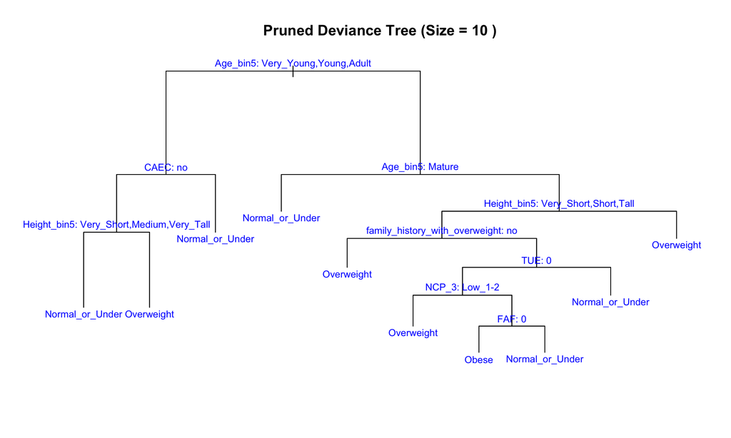

```r
tree_deviance_pruned <- prune.misclass(tree_deviance, best = best_size_dev)
plot(tree_deviance_pruned)
text(tree_deviance_pruned, pretty = 0, cex = 0.8, col = "blue")
title(paste("Pruned Deviance Tree (Size =", best_size_dev, ")"))
```

The pruned tree with 10 nodes is simpler and easier to interpret than the original tree. The main splits are still age, eating frequency (CAEC), and height, which are the most important factors for obesity. For younger people who do not eat outside frequently, height determines whether they are normal weight or overweight. For older people, the tree checks family history, technology use time (TUE), number of meals (NCP_3), and physical activity (FAF) to make the final prediction. The pruned tree removes complex branches that do not help much with prediction, making it a cleaner model that is better for understanding obesity patterns.

#### Test Set Performance

```r
pred_class_dev <- predict(tree_deviance_pruned, newdata = test_data, type = "class")
pred_prob_dev <- predict(tree_deviance_pruned, newdata = test_data, type = "vector")
conf_matrix_dev <- table(Predicted = pred_class_dev, Actual = test_data$Obesity_3)
print(conf_matrix_dev)
```

```
##                  Actual
## Predicted         Normal_or_Under Overweight Obese
##   Normal_or_Under              62         18    10
##   Overweight                    2          6     4
##   Obese                         0          2     3
```

```r
total_error_dev <- mean(pred_class_dev != test_data$Obesity_3)
class_errors_dev <- 1 - diag(conf_matrix_dev) / colSums(conf_matrix_dev)
roc_dev <- multiclass.roc(test_data$Obesity_3, pred_prob_dev)
auc_dev <- auc(roc_dev)
```

**Performance Metrics:**

| Metric | Value |
| --- | --- |
| Total Error Rate | 33.64% |
| Normal_or_Under Error | 3.12% |
| Overweight Error | 76.92% |
| Obese Error | 82.35% |
| Multiclass AUC | .6489 |

On the test set, the model has a total error rate of 33.64%, meaning it correctly predicts about 66% of cases. The model performs well at identifying normal weight people, with only 3.12% error. However, it struggles with overweight and obese groups, with error rates of 76.92% and 82.35%. This means the model often mistakes overweight and obese people as normal weight. The multiclass AUC score of 0.65 shows moderate performance. The confusion matrix reveals that most prediction errors come from confusing overweight and obese cases with normal weight, suggesting the model needs better ability to distinguish between these heavier weight groups.